# ML_Assign

James Campbell

Tuesday, September 16, 2014

# Machine Learning - Course Assignment

```r
## set environment load and reshape data

library("caret")
```

```r
library("stringr")
library("ggplot2")
library("plyr")
library("rattle")
library("rpart.plot")
library("randomForest")
library("scales")
library("knitr")
```

```r
md <- getwd()
setwd("C:/Users/james_000/DataScPrj/MachineLearn/assigndata")

rawdata <- read.csv(file = "pml-training.csv", as.is=TRUE)

setwd(md)

## columns to be retained
keep <- c(TRUE,TRUE,TRUE,TRUE,TRUE,TRUE,TRUE,TRUE,TRUE,TRUE,TRUE,FALSE,FALSE,FALSE,FALSE,FALSE,FALSE,FALSE,FALSE,FALSE,FALSE,FALSE,FALSE,FALSE,FALSE,FALSE,FALSE,FALSE,FALSE,FALSE,FALSE,FALSE,FALSE,FALSE,FALSE,FALSE,TRUE,TRUE,TRUE,TRUE,TRUE,TRUE,TRUE,TRUE,TRUE,TRUE,TRUE,TRUE,TRUE,FALSE,FALSE,FALSE,FALSE,FALSE,FALSE,FALSE,FALSE,FALSE,FALSE,TRUE,TRUE,TRUE,TRUE,TRUE,TRUE,TRUE,TRUE,TRUE,FALSE,FALSE,FALSE,FALSE,FALSE,FALSE,FALSE,FALSE,FALSE,FALSE,FALSE,FALSE,FALSE,FALSE,FALSE,TRUE,TRUE,TRUE,FALSE,FALSE,FALSE,FALSE,FALSE,FALSE,FALSE,FALSE,FALSE,FALSE,FALSE,FALSE,FALSE,FALSE,FALSE,TRUE,FALSE,FALSE,FALSE,FALSE,FALSE,FALSE,FALSE,FALSE,FALSE,FALSE,TRUE,TRUE,TRUE,TRUE,TRUE,TRUE,TRUE,TRUE,TRUE,TRUE,TRUE,TRUE,FALSE,FALSE,FALSE,FALSE,FALSE,FALSE,FALSE,FALSE,FALSE,FALSE,FALSE,FALSE,FALSE,FALSE,FALSE,TRUE,FALSE,FALSE,FALSE,FALSE,FALSE,FALSE,FALSE,FALSE,FALSE,FALSE,TRUE,TRUE,TRUE,TRUE,TRUE,TRUE,TRUE,TRUE,TRUE,TRUE)
basedata <- rawdata[,keep]

##reset some columns to factors
basedata$classe <- as.factor(basedata$classe)
basedata$user_name <- as.factor(basedata$user_name)
```

## Executive Summary

This study looks at the ability to use data gathered from sensors placed on human subjects to determine whether simple exercises where carried out correctly or if not the type of fault. The model was constructed using the random forest model and then refined to minimise the features required while retaining the predictive accuracy.

The final model build used a subset of 24 predictors who were seen to have had the highest impact on model prediction and appears to have an out of sample error of around 1%.

## Data set

The original training data set provided was of 19622 observation with 160 variables.

These recorded

*Subject and timing data (who and when the activity happened)* Sensor data from 3 accelerometers on their body (upper arm, lower arm and belt) and one on the dumbell itself. *Outcome code (Classe) - see below for details

Each sensor recorded 13 different readings continuously over a timeslice (so multiple times per lift)

The dataset also contains columns for 25 summary statistics per sensor for each timeslice. These summary columns only have data entered at the end of each timeslice (otherwise they are blank).

Six subjects where used and carried out a single exercise (perform one set of 10 repetitions of the Unilateral Dumbbell Biceps Curl). From this Five possible outcomes recorded for each lift. These were

*A - Exercise carried out correctly* B - Throwing the elbows to the front *C - Lifting the dumbbell only halfway* D - Lowering the dumbbell only halfway *E - Throwing the hips to the front

The outcomes were confirmed by qualified instructors who monitored the exercise.

Also included was a “testing” data set which contains 20 records. None of these records represent a summary record.

## Model Approach and Cross Validation

Once the summary and time columns were removed there were 52 feature variables and 1 response variable (classe).

As the outcome variable is a factor/classification variable rather than a continuous one it was decided to use a tree approach rather than regression approach. The model adopted was random forest using the *randomForest* R package directly rather than via the *caret train* function.

The allow multiple builds and support cross validation, it was decided to split the dataset in

- Training (60%)
- Testing (20%)
- Validation (20%)

The Validation set was only to be used for the final validation of the selected model using 1 run only.

```r
set.seed(1745)
Intrain <- createDataPartition(y=basedata$classe,p=0.6, list=FALSE)
training <- basedata[Intrain,c(-1,-2,-3,-4,-5,-6,-7)]
base2  <- basedata[-Intrain,c(-1,-2,-3,-4,-5,-6,-7)]
##then split testing into 2
Intest <- createDataPartition(y=base2$classe,p=0.5, list=FALSE)
testing <- base2[Intest,]
validation <- base2[-Intest,]
```

## Initial Model

The first model build was using all 52 variables. This was then tested using the testing set

```r
modTree3 <- randomForest(x=training[,-53],y=training[,53], do.trace=FALSE, xtest=testing[,-53], ytest=testing[,53],ntree=100, importance=TRUE, keep.forest=TRUE)
```

### Model Accuracy

By comparing the predictions from the random Forest model to the actual values for our **testing** dataset we can get a view of the model accuracy (Table 1).

```r
modacc <- confusionMatrix(modTree3$test$predicted,testing$classe)
oa <- modacc$overall[[1]]
```

**Table 1**

```r
print(modacc)
```

```
## Confusion Matrix and Statistics
##
##           Reference
## Prediction    A    B    C    D    E
##          A 1115    2    0    0    0
##          B    1  754    5    0    0
##          C    0    3  675    8    0
##          D    0    0    4  635    1
##          E    0    0    0    0  720
##
## Overall Statistics
##
##                Accuracy : 0.994
##                  95% CI : (0.991, 0.996)
##     No Information Rate : 0.284
##     P-Value [Acc > NIR] : <2e-16
##
##                   Kappa : 0.992
##  Mcnemar's Test P-Value : NA
##
## Statistics by Class:
##
##                      Class: A Class: B Class: C Class: D Class: E
## Sensitivity             0.999    0.993    0.987    0.988    0.999
## Specificity             0.999    0.998    0.997    0.998    1.000
## Pos Pred Value          0.998    0.992    0.984    0.992    1.000
## Neg Pred Value          1.000    0.998    0.997    0.998    1.000
## Prevalence              0.284    0.193    0.174    0.164    0.184
## Detection Rate          0.284    0.192    0.172    0.162    0.184
## Detection Prevalence    0.285    0.194    0.175    0.163    0.184
## Balanced Accuracy       0.999    0.996    0.992    0.993    0.999
```

As can be seen the overall model accuracy is very high at 99.4%.

**Figure 1 - Error rates for forest**

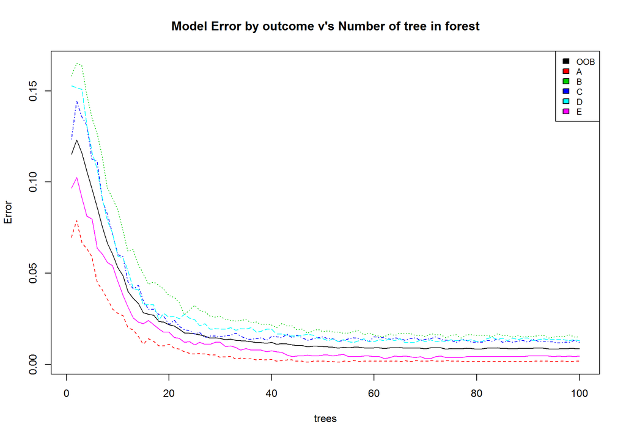

```r
plot(modTree3, main="Model Error by outcome v's Number of tree in forest")
legend("topright", colnames(modTree3$err.rate),col=1:6,cex=0.8,fill=1:6)
```

### Initial Model - Importance of predicators

We can also see by looking at an ordered table and plot of predicators (Table 2 and Figure 2) that is quite likely we could simplify this model by removal of many of the predictors which have very low impact on the model.

**Table 2**

```r
ordimp <-order(-modTree3$importance[,6])
kable(modTree3$importance[ordimp,], digits=3)
```

```
##
##
## |                     |     A|     B|     C|     D|     E| MeanDecreaseAccuracy| MeanDecreaseGini|
## |:--------------------|-----:|-----:|-----:|-----:|-----:|--------------------:|----------------:|
## |roll_belt            | 0.076| 0.095| 0.118| 0.118| 0.221|                0.120|          795.064|
## |magnet_dumbbell_y    | 0.100| 0.116| 0.157| 0.159| 0.064|                0.116|          408.124|
## |roll_forearm         | 0.127| 0.091| 0.175| 0.119| 0.065|                0.116|          369.903|
## |yaw_belt             | 0.112| 0.100| 0.114| 0.152| 0.064|                0.108|          527.878|
## |magnet_dumbbell_z    | 0.113| 0.095| 0.141| 0.113| 0.060|                0.105|          444.500|
## |magnet_dumbbell_x    | 0.108| 0.080| 0.134| 0.117| 0.052|                0.098|          300.591|
## |pitch_belt           | 0.082| 0.125| 0.103| 0.108| 0.039|                0.090|          437.730|
## |pitch_forearm        | 0.092| 0.054| 0.077| 0.114| 0.052|                0.079|          461.872|
## |roll_dumbbell        | 0.037| 0.064| 0.106| 0.073| 0.041|                0.061|          256.772|
## |magnet_belt_z        | 0.042| 0.067| 0.062| 0.080| 0.054|                0.059|          256.666|
## |accel_dumbbell_y     | 0.036| 0.046| 0.099| 0.055| 0.037|                0.052|          232.857|
## |accel_forearm_x      | 0.048| 0.043| 0.050| 0.089| 0.037|                0.052|          194.193|
## |accel_dumbbell_z     | 0.040| 0.040| 0.068| 0.065| 0.043|                0.050|          201.406|
## |magnet_arm_x         | 0.058| 0.038| 0.044| 0.072| 0.029|                0.049|          157.773|
## |magnet_belt_y        | 0.031| 0.047| 0.041| 0.057| 0.040|                0.042|          196.870|
## |yaw_dumbbell         | 0.027| 0.031| 0.063| 0.046| 0.029|                0.038|          158.307|
## |accel_belt_z         | 0.025| 0.032| 0.055| 0.041| 0.031|                0.035|          200.839|
## |roll_arm             | 0.024| 0.036| 0.044| 0.058| 0.022|                0.035|          178.107|
## |total_accel_dumbbell | 0.030| 0.030| 0.035| 0.051| 0.026|                0.034|          144.106|
## |gyros_belt_z         | 0.027| 0.035| 0.045| 0.034| 0.032|                0.034|          182.542|
## |accel_dumbbell_x     | 0.024| 0.029| 0.048| 0.036| 0.030|                0.032|          143.979|
## |magnet_arm_y         | 0.027| 0.030| 0.035| 0.049| 0.021|                0.031|          130.191|
## |accel_forearm_z      | 0.024| 0.026| 0.044| 0.040| 0.022|                0.030|          158.656|
## |accel_arm_x          | 0.035| 0.027| 0.028| 0.045| 0.016|                0.030|          140.105|
## |magnet_belt_x        | 0.023| 0.031| 0.043| 0.042| 0.017|                0.030|          151.608|
## |magnet_forearm_y     | 0.029| 0.024| 0.037| 0.033| 0.019|                0.028|          150.868|
## |total_accel_belt     | 0.023| 0.025| 0.032| 0.028| 0.025|                0.026|          152.923|
## |magnet_forearm_x     | 0.034| 0.016| 0.022| 0.034| 0.020|                0.026|          133.134|
## |pitch_dumbbell       | 0.017| 0.030| 0.038| 0.030| 0.020|                0.026|          118.367|
## |magnet_forearm_z     | 0.025| 0.022| 0.032| 0.032| 0.018|                0.025|          150.786|
## |gyros_dumbbell_y     | 0.024| 0.027| 0.037| 0.024| 0.014|                0.025|          143.252|
## |yaw_arm              | 0.025| 0.020| 0.027| 0.029| 0.012|                0.023|          151.300|
## |magnet_arm_z         | 0.032| 0.022| 0.020| 0.019| 0.008|                0.021|          107.671|
## |accel_belt_x         | 0.024| 0.020| 0.031| 0.015| 0.008|                0.020|           79.179|
## |yaw_forearm          | 0.015| 0.015| 0.026| 0.032| 0.012|                0.019|          106.038|
## |pitch_arm            | 0.018| 0.022| 0.022| 0.021| 0.011|                0.019|          104.879|
## |accel_forearm_y      | 0.020| 0.015| 0.027| 0.018| 0.009|                0.018|           87.224|
## |accel_arm_y          | 0.017| 0.020| 0.019| 0.020| 0.010|                0.017|           91.787|
## |accel_belt_y         | 0.012| 0.019| 0.026| 0.020| 0.010|                0.017|           72.271|
## |gyros_belt_x         | 0.018| 0.009| 0.029| 0.013| 0.004|                0.015|           59.920|
## |gyros_belt_y         | 0.010| 0.018| 0.018| 0.019| 0.006|                0.014|           68.384|
## |accel_arm_z          | 0.019| 0.011| 0.016| 0.011| 0.006|                0.013|           73.009|
## |gyros_arm_x          | 0.019| 0.013| 0.008| 0.012| 0.006|                0.012|           81.933|
## |gyros_dumbbell_x     | 0.005| 0.015| 0.018| 0.012| 0.008|                0.011|           81.108|
## |gyros_forearm_y      | 0.011| 0.014| 0.009| 0.010| 0.005|                0.010|           76.248|
## |gyros_arm_y          | 0.010| 0.014| 0.006| 0.011| 0.006|                0.009|           77.638|
## |total_accel_forearm  | 0.013| 0.007| 0.010| 0.009| 0.005|                0.009|           62.657|
## |total_accel_arm      | 0.008| 0.008| 0.011| 0.011| 0.007|                0.009|           60.091|
## |gyros_forearm_x      | 0.004| 0.007| 0.007| 0.009| 0.003|                0.006|           46.845|
## |gyros_forearm_z      | 0.004| 0.009| 0.006| 0.005| 0.002|                0.005|           51.552|
## |gyros_dumbbell_z     | 0.003| 0.007| 0.005| 0.006| 0.004|                0.005|           53.523|
## |gyros_arm_z          | 0.007| 0.004| 0.004| 0.004| 0.003|                0.005|           36.303|
```

**Figure 2**

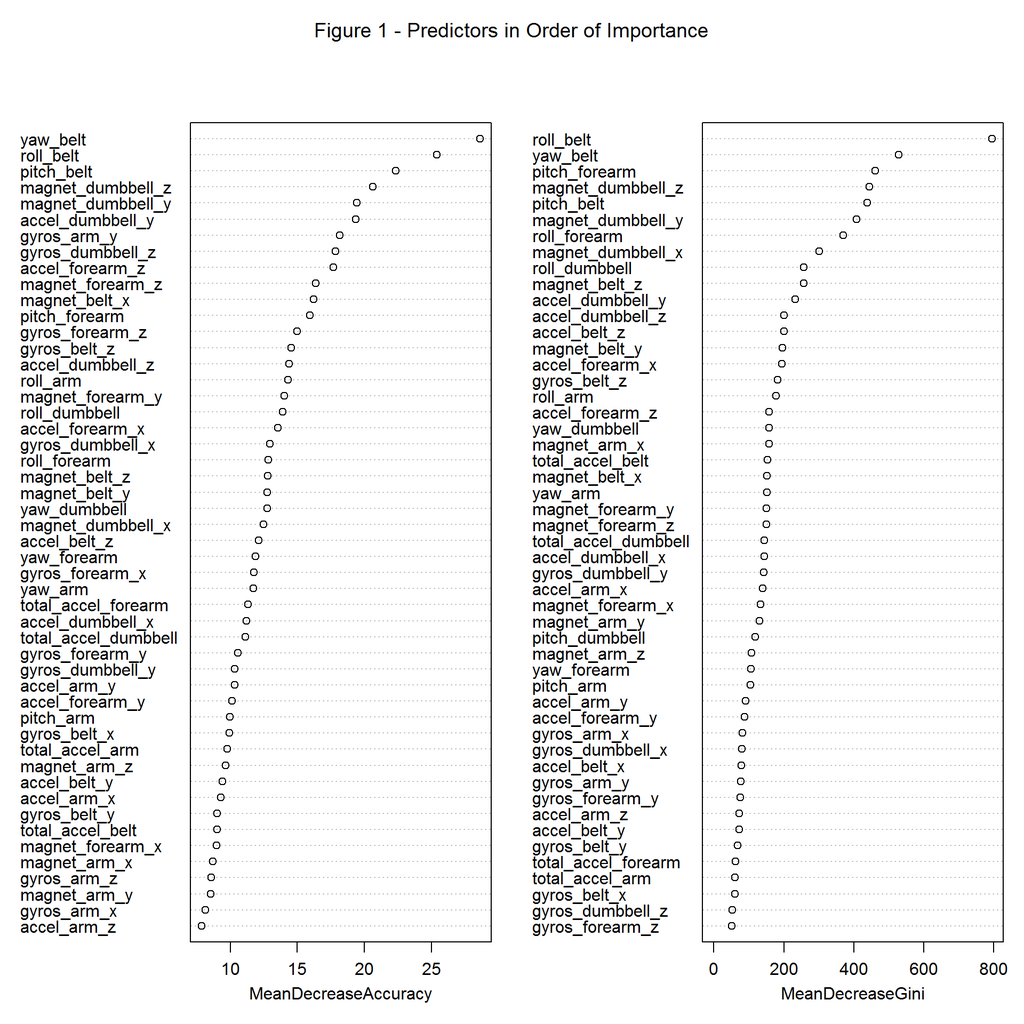

```r
varImpPlot(modTree3, n.var=50, main="Figure 1 - Predictors in Order of Importance")
```

## Second Model

The second model attempted to reduce the predicator set based on their overall importance to the model accuracy. This was done by only using predictors whose importance was 0.03 or greater.

```r
keepvar <- c(modTree3$importance[,6]>0.03,FALSE)
numvar <- sum(keepvar)
modTree4 <- randomForest(x=training[,keepvar],y=training[,53], do.trace=FALSE, xtest=testing[,keepvar], ytest=testing[,53],ntree=100, importance=TRUE, keep.forest=TRUE)
```

```r
modacc <- confusionMatrix(modTree4$test$predicted,testing$classe)
oa <- modacc$overall[[1]]
```

**Table 3**

```r
print(modacc)
```

```
## Confusion Matrix and Statistics
##
##           Reference
## Prediction    A    B    C    D    E
##          A 1113    6    0    0    0
##          B    2  747    9    0    0
##          C    1    6  674    5    1
##          D    0    0    1  638    2
##          E    0    0    0    0  718
##
## Overall Statistics
##
##                Accuracy : 0.992
##                  95% CI : (0.988, 0.994)
##     No Information Rate : 0.284
##     P-Value [Acc > NIR] : <2e-16
##
##                   Kappa : 0.989
##  Mcnemar's Test P-Value : NA
##
## Statistics by Class:
##
##                      Class: A Class: B Class: C Class: D Class: E
## Sensitivity             0.997    0.984    0.985    0.992    0.996
## Specificity             0.998    0.997    0.996    0.999    1.000
## Pos Pred Value          0.995    0.985    0.981    0.995    1.000
## Neg Pred Value          0.999    0.996    0.997    0.998    0.999
## Prevalence              0.284    0.193    0.174    0.164    0.184
## Detection Rate          0.284    0.190    0.172    0.163    0.183
## Detection Prevalence    0.285    0.193    0.175    0.163    0.183
## Balanced Accuracy       0.998    0.990    0.991    0.996    0.998
```

**Figure 3 - Error rates for forest**

[figure not shown]

```r
plot(modTree3, main="Model Error by outcome v's Number of tree in forest")
legend("topright", colnames(modTree4$err.rate),col=1:6,cex=0.8,fill=1:6)
```

### Reduced Model - Importance of predicators

A table and plot (Table4 and Figure 4) of predictor importance is shown below.

**Table 4**

```r
ordimp <-order(-modTree4$importance[,6])
kable(modTree4$importance[ordimp,], digits=3)
```

```
##
##
## |                     |     A|     B|     C|     D|     E| MeanDecreaseAccuracy| MeanDecreaseGini|
## |:--------------------|-----:|-----:|-----:|-----:|-----:|--------------------:|----------------:|
## |roll_belt            | 0.096| 0.130| 0.151| 0.162| 0.229|                0.148|          969.318|
## |magnet_dumbbell_y    | 0.129| 0.151| 0.203| 0.189| 0.082|                0.147|          532.972|
## |yaw_belt             | 0.140| 0.124| 0.164| 0.203| 0.083|                0.141|          724.065|
## |magnet_dumbbell_z    | 0.155| 0.124| 0.188| 0.152| 0.072|                0.139|          594.782|
## |roll_forearm         | 0.160| 0.103| 0.205| 0.132| 0.078|                0.137|          495.011|
## |magnet_dumbbell_x    | 0.138| 0.112| 0.173| 0.134| 0.064|                0.125|          420.636|
## |pitch_belt           | 0.097| 0.152| 0.130| 0.137| 0.043|                0.110|          542.051|
## |pitch_forearm        | 0.119| 0.070| 0.088| 0.137| 0.063|                0.097|          602.520|
## |magnet_belt_z        | 0.067| 0.086| 0.102| 0.103| 0.061|                0.082|          371.496|
## |accel_dumbbell_y     | 0.062| 0.074| 0.133| 0.095| 0.057|                0.081|          347.634|
## |roll_dumbbell        | 0.052| 0.085| 0.119| 0.090| 0.056|                0.077|          362.564|
## |accel_dumbbell_z     | 0.051| 0.056| 0.086| 0.079| 0.058|                0.064|          261.845|
## |accel_forearm_x      | 0.056| 0.051| 0.055| 0.104| 0.037|                0.059|          294.339|
## |magnet_belt_y        | 0.042| 0.062| 0.069| 0.086| 0.045|                0.058|          288.884|
## |yaw_dumbbell         | 0.048| 0.050| 0.088| 0.064| 0.045|                0.058|          242.867|
## |accel_belt_z         | 0.044| 0.050| 0.084| 0.061| 0.044|                0.055|          331.036|
## |roll_arm             | 0.035| 0.064| 0.074| 0.080| 0.033|                0.054|          284.754|
## |magnet_arm_x         | 0.070| 0.041| 0.051| 0.069| 0.030|                0.053|          219.609|
## |accel_dumbbell_x     | 0.045| 0.043| 0.083| 0.063| 0.033|                0.052|          205.830|
## |total_accel_dumbbell | 0.049| 0.047| 0.053| 0.077| 0.037|                0.052|          230.373|
## |accel_forearm_z      | 0.040| 0.045| 0.079| 0.060| 0.035|                0.050|          262.428|
## |accel_arm_x          | 0.053| 0.038| 0.042| 0.073| 0.024|                0.046|          235.600|
## |gyros_belt_z         | 0.035| 0.051| 0.063| 0.045| 0.034|                0.044|          258.958|
## |magnet_arm_y         | 0.035| 0.045| 0.053| 0.065| 0.027|                0.043|          229.545|
```

**Figure 4**

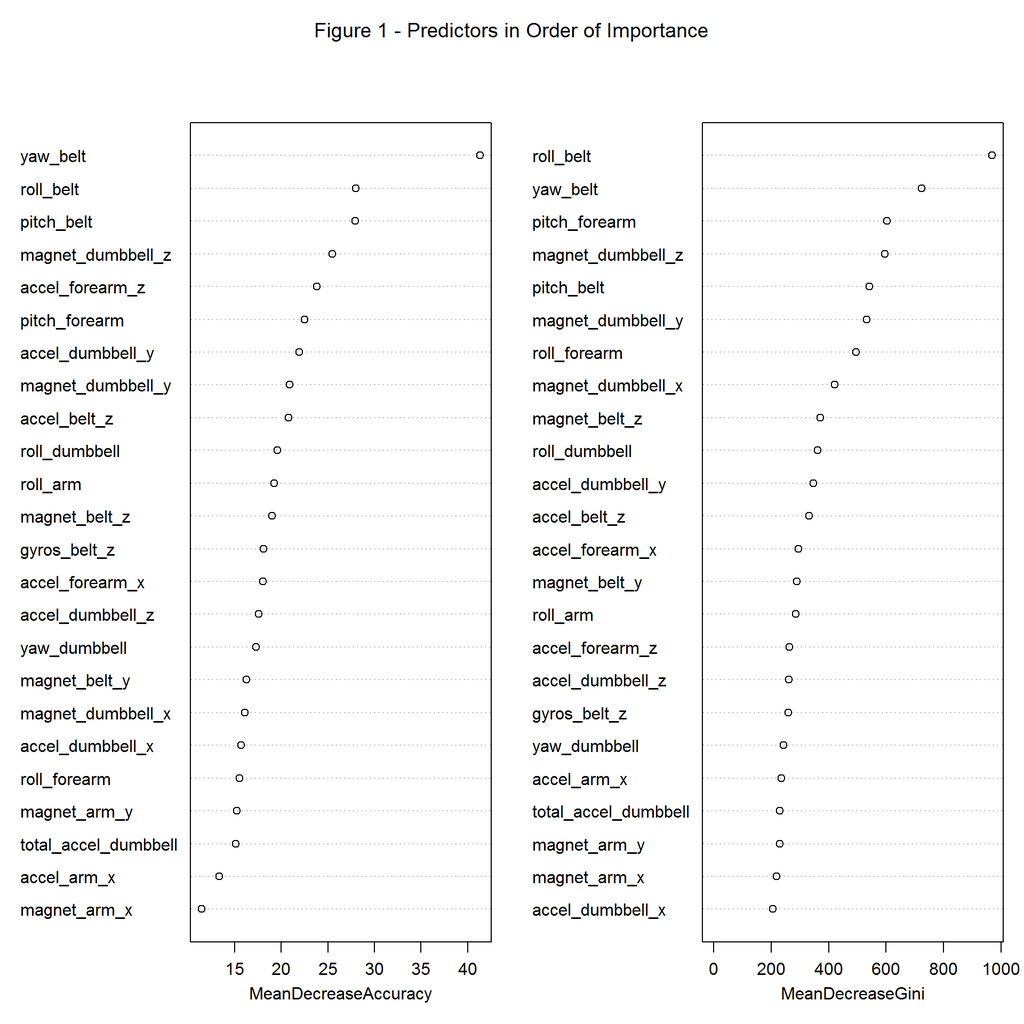

```r
varImpPlot(modTree4, main="Figure 1 - Predictors in Order of Importance")
```

## Validation of Second Model

The last part of the model design and build was to test it against our reserved validation set to see how well it performed on this data set

```r
val_out <- predict(modTree4, validation)
```

### Out of sample error

**Table 5 - Confusion Matrix of Reduced Model and Validation set**

```r
confusionMatrix(val_out,validation$classe)
```

```
## Confusion Matrix and Statistics
##
##           Reference
## Prediction    A    B    C    D    E
##          A 1112    2    0    0    0
##          B    4  754   15    0    0
##          C    0    3  666    6    3
##          D    0    0    3  637    5
##          E    0    0    0    0  713
##
## Overall Statistics
##
##                Accuracy : 0.99
##                  95% CI : (0.986, 0.992)
##     No Information Rate : 0.284
##     P-Value [Acc > NIR] : <2e-16
##
##                   Kappa : 0.987
##  Mcnemar's Test P-Value : NA
##
## Statistics by Class:
##
##                      Class: A Class: B Class: C Class: D Class: E
## Sensitivity             0.996    0.993    0.974    0.991    0.989
## Specificity             0.999    0.994    0.996    0.998    1.000
## Pos Pred Value          0.998    0.975    0.982    0.988    1.000
## Neg Pred Value          0.999    0.998    0.994    0.998    0.998
## Prevalence              0.284    0.193    0.174    0.164    0.184
## Detection Rate          0.283    0.192    0.170    0.162    0.182
## Detection Prevalence    0.284    0.197    0.173    0.164    0.182
## Balanced Accuracy       0.998    0.994    0.985    0.994    0.994
```

As can be seen in the confusion matrix below and as expected the accuracy level is slightly lower than the training or testign sets but is still very accurate at around 99% overall. All outcomes are being predicted with very high Sensitivity and Specificity and this model appears to be very robust for this data.

Based on above the **out of sample error should be around 1%**. This should not vary between the outcome value significantly

## Conclussions

In conclusion the use of the random forest predictive model was very successful with this type of data, It was also possible to use a smaller subset of predictors without having a significant impact on accuracy. It may be possible to also reduce the number of trees required as error rates in predictions leveled off at around 60 trees but given the fairly rapid calculation times this wasnt seen as neccesary.

The working data used in this study was obtained from the below paper and used under public licence with permission

*Velloso, E.; Bulling, A.; Gellersen, H.; Ugulino, W.; Fuks, H. Qualitative Activity Recognition of Weight Lifting Exercises. Proceedings of 4th International Conference in Cooperation with SIGCHI (Augmented Human ’13) . Stuttgart, Germany: ACM SIGCHI, 2013.*

Read more: http://groupware.les.inf.puc-rio.br/har#ixzz3DlhUl8eS